# Shubham Sharma

Data Science & Business Analytics Intern @TSF

Task #5 : Exploratory Data Analysis : Sports (Indian Premier League)

Dataset 1 : matches.csv (https://bit.ly/34SRn3b)

Dataset 2: deliveries.csv(https://bit.ly/34SRn3b)

# Step-1 Importing Modules

```python
import pandas as pd
import matplotlib.pyplot as plt
from sklearn import linear_model
```

# Step-2 Importing First Dataset

Let’s start by reading the csv file to Pandas DataFrame.

```python
ipl_matches = pd.read_csv("C:\\Users\shubham\Desktop\matches.csv")
ipl_matches
```

|  | id | season | city | date | team1 | team2 | toss_winner | toss_decision | result | dl_applied | winner | win_by_runs | win_by_wickets | player_of_match | venue | umpire1 | umpire2 | umpire3 |
| --- | --- | --- | --- | --- | --- | --- | --- | --- | --- | --- | --- | --- | --- | --- | --- | --- | --- | --- |
| 0 | 1 | 2017 | Hyderabad | 05-04-2017 | Sunrisers Hyderabad | Royal Challengers Bangalore | Royal Challengers Bangalore | field | normal | 0 | Sunrisers Hyderabad | 35 | 0 | Yuvraj Singh | Rajiv Gandhi International Stadium, Uppal | AY Dandekar | NJ Llong | NaN |
| 1 | 2 | 2017 | Pune | 06-04-2017 | Mumbai Indians | Rising Pune Supergiant | Rising Pune Supergiant | field | normal | 0 | Rising Pune Supergiant | 0 | 7 | SPD Smith | Maharashtra Cricket Association Stadium | A Nand Kishore | S Ravi | NaN |
| 2 | 3 | 2017 | Rajkot | 07-04-2017 | Gujarat Lions | Kolkata Knight Riders | Kolkata Knight Riders | field | normal | 0 | Kolkata Knight Riders | 0 | 10 | CA Lynn | Saurashtra Cricket Association Stadium | Nitin Menon | CK Nandan | NaN |
| 3 | 4 | 2017 | Indore | 08-04-2017 | Rising Pune Supergiant | Kings XI Punjab | Kings XI Punjab | field | normal | 0 | Kings XI Punjab | 0 | 6 | GJ Maxwell | Holkar Cricket Stadium | AK Chaudhary | C Shamshuddin | NaN |
| 4 | 5 | 2017 | Bangalore | 08-04-2017 | Royal Challengers Bangalore | Delhi Daredevils | Royal Challengers Bangalore | bat | normal | 0 | Royal Challengers Bangalore | 15 | 0 | KM Jadhav | M Chinnaswamy Stadium | NaN | NaN | NaN |
| ... | ... | ... | ... | ... | ... | ... | ... | ... | ... | ... | ... | ... | ... | ... | ... | ... | ... | ... |
| 751 | 11347 | 2019 | Mumbai | 05-05-2019 | Kolkata Knight Riders | Mumbai Indians | Mumbai Indians | field | normal | 0 | Mumbai Indians | 0 | 9 | HH Pandya | Wankhede Stadium | Nanda Kishore | O Nandan | S Ravi |
| 752 | 11412 | 2019 | Chennai | 07-05-2019 | Chennai Super Kings | Mumbai Indians | Chennai Super Kings | bat | normal | 0 | Mumbai Indians | 0 | 6 | AS Yadav | M. A. Chidambaram Stadium | Nigel Llong | Nitin Menon | Ian Gould |
| 753 | 11413 | 2019 | Visakhapatnam | 08-05-2019 | Sunrisers Hyderabad | Delhi Capitals | Delhi Capitals | field | normal | 0 | Delhi Capitals | 0 | 2 | RR Pant | ACA-VDCA Stadium | NaN | NaN | NaN |
| 754 | 11414 | 2019 | Visakhapatnam | 10-05-2019 | Delhi Capitals | Chennai Super Kings | Chennai Super Kings | field | normal | 0 | Chennai Super Kings | 0 | 6 | F du Plessis | ACA-VDCA Stadium | Sundaram Ravi | Bruce Oxenford | Chettithody Shamshuddin |
| 755 | 11415 | 2019 | Hyderabad | 12-05-2019 | Mumbai Indians | Chennai Super Kings | Mumbai Indians | bat | normal | 0 | Mumbai Indians | 1 | 0 | JJ Bumrah | Rajiv Gandhi Intl. Cricket Stadium | Nitin Menon | Ian Gould | Nigel Llong |

756 rows × 18 columns

# Import Second Dataset

```python
ipl_delveries = pd.read_csv("C:\\Users\shubham\Desktop\deliveries.csv")
ipl_deliveries
```

|  | match_id | inning | batting_team | bowling_team | over | ball | batsman | non_striker | bowler | is_super_over | ... | bye_runs | legbye_runs | noball_runs | penalty_runs | batsman_runs | extra_runs | total_runs | player_dismissed | dismissal_kind | fielder |
| --- | --- | --- | --- | --- | --- | --- | --- | --- | --- | --- | --- | --- | --- | --- | --- | --- | --- | --- | --- | --- | --- |
| 0 | 1 | 1 | Sunrisers Hyderabad | Royal Challengers Bangalore | 1 | 1 | DA Warner | S Dhawan | TS Mills | 0 | ... | 0 | 0 | 0 | 0 | 0 | 0 | 0 | NaN | NaN | NaN |
| 1 | 1 | 1 | Sunrisers Hyderabad | Royal Challengers Bangalore | 1 | 2 | DA Warner | S Dhawan | TS Mills | 0 | ... | 0 | 0 | 0 | 0 | 0 | 0 | 0 | NaN | NaN | NaN |
| 2 | 1 | 1 | Sunrisers Hyderabad | Royal Challengers Bangalore | 1 | 3 | DA Warner | S Dhawan | TS Mills | 0 | ... | 0 | 0 | 0 | 0 | 4 | 0 | 4 | NaN | NaN | NaN |
| 3 | 1 | 1 | Sunrisers Hyderabad | Royal Challengers Bangalore | 1 | 4 | DA Warner | S Dhawan | TS Mills | 0 | ... | 0 | 0 | 0 | 0 | 0 | 0 | 0 | NaN | NaN | NaN |
| 4 | 1 | 1 | Sunrisers Hyderabad | Royal Challengers Bangalore | 1 | 5 | DA Warner | S Dhawan | TS Mills | 0 | ... | 0 | 0 | 0 | 0 | 0 | 2 | 2 | NaN | NaN | NaN |
| ... | ... | ... | ... | ... | ... | ... | ... | ... | ... | ... | ... | ... | ... | ... | ... | ... | ... | ... | ... | ... | ... |
| 179073 | 11415 | 2 | Chennai Super Kings | Mumbai Indians | 20 | 2 | RA Jadeja | SR Watson | SL Malinga | 0 | ... | 0 | 0 | 0 | 0 | 1 | 0 | 1 | NaN | NaN | NaN |
| 179074 | 11415 | 2 | Chennai Super Kings | Mumbai Indians | 20 | 3 | SR Watson | RA Jadeja | SL Malinga | 0 | ... | 0 | 0 | 0 | 0 | 2 | 0 | 2 | NaN | NaN | NaN |
| 179075 | 11415 | 2 | Chennai Super Kings | Mumbai Indians | 20 | 4 | SR Watson | RA Jadeja | SL Malinga | 0 | ... | 0 | 0 | 0 | 0 | 1 | 0 | 1 | SR Watson | run out | KH Pandya |
| 179076 | 11415 | 2 | Chennai Super Kings | Mumbai Indians | 20 | 5 | SN Thakur | RA Jadeja | SL Malinga | 0 | ... | 0 | 0 | 0 | 0 | 2 | 0 | 2 | NaN | NaN | NaN |
| 179077 | 11415 | 2 | Chennai Super Kings | Mumbai Indians | 20 | 6 | SN Thakur | RA Jadeja | SL Malinga | 0 | ... | 0 | 0 | 0 | 0 | 0 | 0 | 0 | SN Thakur | lbw | NaN |

179078 rows × 21 columns

# Step-3 Data Preparation and Cleaning

```python
ipl_matches.info()
```

```
<class 'pandas.core.frame.DataFrame'>
RangeIndex: 756 entries, 0 to 755
Data columns (total 18 columns):
id                 756 non-null int64
season             756 non-null int64
city               749 non-null object
date               756 non-null object
team1              756 non-null object
team2              756 non-null object
toss_winner        756 non-null object
toss_decision      756 non-null object
result             756 non-null object
dl_applied         756 non-null int64
winner             752 non-null object
win_by_runs        756 non-null int64
win_by_wickets     756 non-null int64
player_of_match    752 non-null object
venue              756 non-null object
umpire1            754 non-null object
umpire2            754 non-null object
umpire3            119 non-null object
dtypes: int64(5), object(13)
memory usage: 106.4+ KB
```

```python
ipl_matches.describe()
```

|  | id | season | dl_applied | win_by_runs | win_by_wickets |
| --- | --- | --- | --- | --- | --- |
| count | 756.000000 | 756.000000 | 756.000000 | 756.000000 | 756.000000 |
| mean | 1792.178571 | 2013.444444 | 0.025132 | 13.283069 | 3.350529 |
| std | 3464.478148 | 3.366895 | 0.156630 | 23.471144 | 3.387963 |
| min | 1.000000 | 2008.000000 | 0.000000 | 0.000000 | 0.000000 |
| 25% | 189.750000 | 2011.000000 | 0.000000 | 0.000000 | 0.000000 |
| 50% | 378.500000 | 2013.000000 | 0.000000 | 0.000000 | 4.000000 |
| 75% | 567.250000 | 2016.000000 | 0.000000 | 19.000000 | 6.000000 |
| max | 11415.000000 | 2019.000000 | 1.000000 | 146.000000 | 10.000000 |

## Observations:

The following inferences can be made from the describe() method:

The .csv file has data of IPL matches starting from the season 2008 to 2019.

The biggest margin of victory for the team batting first(win_by_runs) is 146 runs.

The biggest victory of the team batting second(win_by_wickets) is by 10 wickets

```python
ipl_matches.columns
```

```
Index(['id', 'season', 'city', 'date', 'team1', 'team2', 'toss_winner',
       'toss_decision', 'result', 'dl_applied', 'winner', 'win_by_runs',
       'win_by_wickets', 'player_of_match', 'venue', 'umpire1', 'umpire2',
       'umpire3'],
      dtype='object')
```

#### Let’s view the unique values of each column to help us understand the dataset better.

```python
for col in ipl_matches:
    print(ipl_matches[col].unique())
```

[output not shown]

[output cut: 252 more lines]

[output not shown]

# The dataset has 18 columns.

```python
#the first index that doesn't contain a NaN value
ipl_matches.umpire3.first_valid_index()
```

```
636
```

### This is mere glance of the DataFrame through its columns indicates the presence of NaN values in the ‘umpire3’ column. Let’s see the count of NaN values in the column

```python
#Confirming the first valid index
ipl_matches.loc[633:640]
```

|  | id | season | city | date | team1 | team2 | toss_winner | toss_decision | result | dl_applied | winner | win_by_runs | win_by_wickets | player_of_match | venue | umpire1 | umpire2 | umpire3 |
| --- | --- | --- | --- | --- | --- | --- | --- | --- | --- | --- | --- | --- | --- | --- | --- | --- | --- | --- |
| 633 | 634 | 2016 | Delhi | 25-05-2016 | Sunrisers Hyderabad | Kolkata Knight Riders | Kolkata Knight Riders | field | normal | 0 | Sunrisers Hyderabad | 22 | 0 | MC Henriques | Feroz Shah Kotla | M Erasmus | C Shamshuddin | NaN |
| 634 | 635 | 2016 | Delhi | 27-05-2016 | Gujarat Lions | Sunrisers Hyderabad | Sunrisers Hyderabad | field | normal | 0 | Sunrisers Hyderabad | 0 | 4 | DA Warner | Feroz Shah Kotla | M Erasmus | CK Nandan | NaN |
| 635 | 636 | 2016 | Bangalore | 29-05-2016 | Sunrisers Hyderabad | Royal Challengers Bangalore | Sunrisers Hyderabad | bat | normal | 0 | Sunrisers Hyderabad | 8 | 0 | BCJ Cutting | M Chinnaswamy Stadium | HDPK Dharmasena | BNJ Oxenford | NaN |
| 636 | 7894 | 2018 | Mumbai | 07-04-2018 | Mumbai Indians | Chennai Super Kings | Chennai Super Kings | field | normal | 0 | Chennai Super Kings | 0 | 1 | DJ Bravo | Wankhede Stadium | Chris Gaffaney | A Nanda Kishore | Anil Chaudhary |
| 637 | 7895 | 2018 | Mohali | 08-04-2018 | Delhi Daredevils | Kings XI Punjab | Kings XI Punjab | field | normal | 0 | Kings XI Punjab | 0 | 6 | KL Rahul | Punjab Cricket Association IS Bindra Stadium, ... | Rod Tucker | K Ananthapadmanabhan | Nitin Menon |
| 638 | 7896 | 2018 | Kolkata | 08-04-2018 | Royal Challengers Bangalore | Kolkata Knight Riders | Kolkata Knight Riders | field | normal | 0 | Kolkata Knight Riders | 0 | 4 | SP Narine | Eden Gardens | C Shamshuddin | A.D Deshmukh | S Ravi |
| 639 | 7897 | 2018 | Hyderabad | 09-04-2018 | Rajasthan Royals | Sunrisers Hyderabad | Sunrisers Hyderabad | field | normal | 0 | Sunrisers Hyderabad | 0 | 9 | S Dhawan | Rajiv Gandhi International Stadium, Uppal | Nigel Llong | Vineet Kulkarni | O Nandan |
| 640 | 7898 | 2018 | Chennai | 10-04-2018 | Kolkata Knight Riders | Chennai Super Kings | Chennai Super Kings | field | normal | 0 | Chennai Super Kings | 0 | 5 | SW Billings | MA Chidambaram Stadium, Chepauk | Anil Chaudhary | Chris Gaffaney | A Nanda Kishore |

### It’s imperative to know the count of NaN values for each column before we proceed further.

```python
ipl_matches.isnull().sum()
```

```
id                   0
season               0
city                 7
date                 0
team1                0
team2                0
toss_winner          0
toss_decision        0
result               0
dl_applied           0
winner               4
win_by_runs          0
win_by_wickets       0
player_of_match      4
venue                0
umpire1              2
umpire2              2
umpire3            637
dtype: int64
```

```python
ipl_matches = ipl_matches.drop(columns=['umpire3'], axis=1)
```

##### The column ‘umpire3’ has a significant number of NaN values. As the off-field umpire parameter is insignificant, we can drop this column. The other columns that have Nan values are of type object(Pandas equivalent of Python String data type) and are very few in number(<=7)

```python
ipl_deliveries.info()
```

```
<class 'pandas.core.frame.DataFrame'>
RangeIndex: 179078 entries, 0 to 179077
Data columns (total 21 columns):
match_id            179078 non-null int64
inning              179078 non-null int64
batting_team        179078 non-null object
bowling_team        179078 non-null object
over                179078 non-null int64
ball                179078 non-null int64
batsman             179078 non-null object
non_striker         179078 non-null object
bowler              179078 non-null object
is_super_over       179078 non-null int64
wide_runs           179078 non-null int64
bye_runs            179078 non-null int64
legbye_runs         179078 non-null int64
noball_runs         179078 non-null int64
penalty_runs        179078 non-null int64
batsman_runs        179078 non-null int64
extra_runs          179078 non-null int64
total_runs          179078 non-null int64
player_dismissed    8834 non-null object
dismissal_kind      8834 non-null object
fielder             6448 non-null object
dtypes: int64(13), object(8)
memory usage: 28.7+ MB
```

## For Better Data Analysis Replacing all the IPL Team Names By Shorter Names

```python
#Replacing the Full names of IPL TEAMS by short names
ipl_matches.replace(['Mumbai Indians','Kolkata Knight Riders','Royal Challengers Bangalore','Deccan Chargers','Chennai Super Kings',
                 'Rajasthan Royals','Delhi Daredevils','Gujarat Lions','Kings XI Punjab',
                 'Sunrisers Hyderabad','Rising Pune Supergiants','Kochi Tuskers Kerala','Pune Warriors','Rising Pune Supergiant']
                ,['MI','KKR','RCB','DC','CSK','RR','DD','GL','KXIP','SRH','RPS','KTK','PW','RPS'],inplace=True)
```

```python
#Replacing the Full names of IPL TEAMS by short names
ipl_deliveries.replace(['Mumbai Indians','Kolkata Knight Riders','Royal Challengers Bangalore','Deccan Chargers','Chennai Super Kings',
                 'Rajasthan Royals','Delhi Daredevils','Gujarat Lions','Kings XI Punjab',
                 'Sunrisers Hyderabad','Rising Pune Supergiants','Kochi Tuskers Kerala','Pune Warriors','Rising Pune Supergiant']
                ,['MI','KKR','RCB','DC','CSK','RR','DD','GL','KXIP','SRH','RPS','KTK','PW','RPS'],inplace=True)
```

```python
# merging seasons column in deliveries dataset which will be helpful in further analysis for each season
ipl_deliveries = ipl_deliveries.merge(ipl_matches["season"], left_on=ipl_deliveries.index, right_on=ipl_matches.index)
```

### Step-4 Exploratory Data Analysis(EDA) is an approach to analyzing data sets to summarize their main characteristics, often with visual methods.

#### Now that our data set has been cleaned up, it’s time to do the in-depth analysis and visualization.

##### Let’s begin by importingmatplotlib.pyplot and seaborn

```python
import seaborn as sns
import matplotlib
import matplotlib.pyplot as plt
%matplotlib inline
sns.color_palette("Paired")
matplotlib.rcParams['font.size'] = 14
matplotlib.rcParams['figure.figsize'] = (12, 8)
matplotlib.rcParams['figure.facecolor'] = '#00000000'
```

## ANALYSIS-1

### The team with the most number of wins per season

### Each IPL season has a fair share of excitement and adulation. No team other than Chennai Super Kings(in 2010 and 2011) was able to win the IPL trophy in succession. That is a testimony to the unpredictability of IPL.

```python
teams_per_season = ipl_matches.groupby('season')['winner'].value_counts()
teams_per_season
```

```
season  winner
2008    RR        13
        KXIP      10
        CSK        9
        DD         7
        MI         7
                  ..
2019    KKR        6
        KXIP       6
        SRH        6
        RCB        5
        RR         5
Name: winner, Length: 100, dtype: int64
```

### Let’s analyze the team with the most wins in each season.

```python
"""
for i, v in win_per_season.iteritems():
    print(i, v)

for items in win_per_season.iteritems():
    print(items)
"""
year = 2008
win_per_season_df = pd.DataFrame(columns=['year', 'team', 'wins'])
for items in teams_per_season.iteritems():
    if items[0][0]==year:
        print(items)
        win_series = pd.DataFrame({
            'year': [items[0][0]],
            'team': [items[0][1]],
            'wins': [items[1]]
        })
        win_per_season_df = win_per_season_df.append(win_series)
        year += 1
```

[output not shown]

## The number of wins is a discrete value. Hence, we will plot a bar chart(barplot in Seaborn).

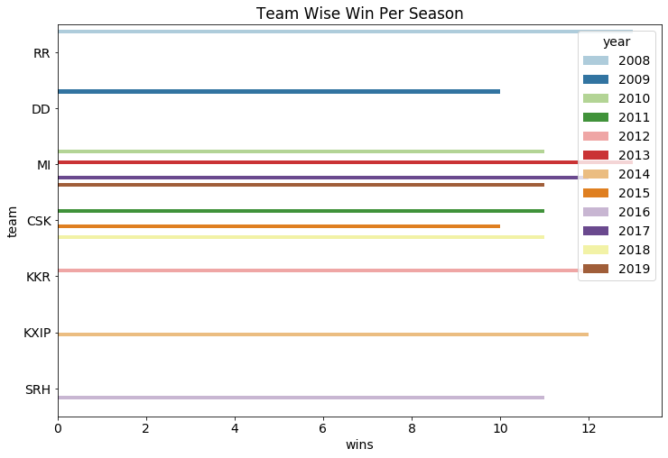

```python
plt.title("Team Wise Win Per Season")
sns.barplot('wins', 'team', hue='year', data=win_per_season_df, palette='Paired');
```

## Observations:

### Mumbai Indians has secured the most wins in four seasons(2010, 2013, 2017, and 2019).

### -------------------------------------------------------------------------------------------------------------------------------------------------------------

## ANALYSIS-2

## The venue that hosted the maximum number of matches

```python
venue_ser = ipl_matches['venue'].value_counts()
```

```python
venue_df = pd.DataFrame(columns=['venue', 'matches'])
for items in venue_ser.iteritems():
    temp_df = pd.DataFrame({
        'venue':[items[0]],
        'matches':[items[1]]
    })
    venue_df = venue_df.append(temp_df, ignore_index=True)
```

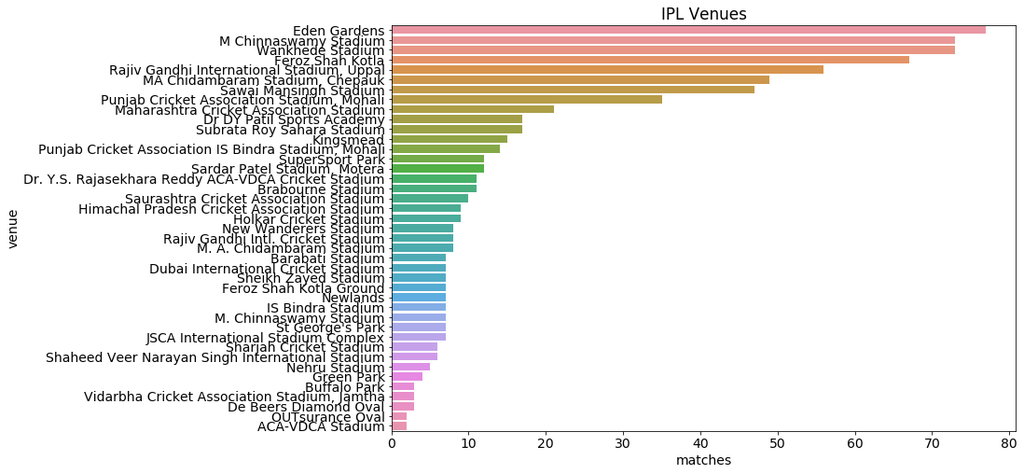

```python
plt.title("IPL Venues")
sns.barplot(x='matches',y='venue', data=venue_df);
```

# Observations:

## => Eden Gardens has hosted the maximum number of IPL matches followed by Wankhede Stadium and M Chinnaswamy Stadium.

### -------------------------------------------------------------------------------------------------------------------------------------------------------------

```python
venue_df
```

|  | venue | matches |
| --- | --- | --- |
| 0 | Eden Gardens | 77 |
| 1 | M Chinnaswamy Stadium | 73 |
| 2 | Wankhede Stadium | 73 |
| 3 | Feroz Shah Kotla | 67 |
| 4 | Rajiv Gandhi International Stadium, Uppal | 56 |
| 5 | MA Chidambaram Stadium, Chepauk | 49 |
| 6 | Sawai Mansingh Stadium | 47 |
| 7 | Punjab Cricket Association Stadium, Mohali | 35 |
| 8 | Maharashtra Cricket Association Stadium | 21 |
| 9 | Dr DY Patil Sports Academy | 17 |
| 10 | Subrata Roy Sahara Stadium | 17 |
| 11 | Kingsmead | 15 |
| 12 | Punjab Cricket Association IS Bindra Stadium, ... | 14 |
| 13 | SuperSport Park | 12 |
| 14 | Sardar Patel Stadium, Motera | 12 |
| 15 | Dr. Y.S. Rajasekhara Reddy ACA-VDCA Cricket St... | 11 |
| 16 | Brabourne Stadium | 11 |
| 17 | Saurashtra Cricket Association Stadium | 10 |
| 18 | Himachal Pradesh Cricket Association Stadium | 9 |
| 19 | Holkar Cricket Stadium | 9 |
| 20 | New Wanderers Stadium | 8 |
| 21 | Rajiv Gandhi Intl. Cricket Stadium | 8 |
| 22 | M. A. Chidambaram Stadium | 8 |
| 23 | Barabati Stadium | 7 |
| 24 | Dubai International Cricket Stadium | 7 |
| 25 | Sheikh Zayed Stadium | 7 |
| 26 | Feroz Shah Kotla Ground | 7 |
| 27 | Newlands | 7 |
| 28 | IS Bindra Stadium | 7 |
| 29 | M. Chinnaswamy Stadium | 7 |
| 30 | St George's Park | 7 |
| 31 | JSCA International Stadium Complex | 7 |
| 32 | Sharjah Cricket Stadium | 6 |
| 33 | Shaheed Veer Narayan Singh International Stadium | 6 |
| 34 | Nehru Stadium | 5 |
| 35 | Green Park | 4 |
| 36 | Buffalo Park | 3 |
| 37 | Vidarbha Cricket Association Stadium, Jamtha | 3 |
| 38 | De Beers Diamond Oval | 3 |
| 39 | OUTsurance Oval | 2 |
| 40 | ACA-VDCA Stadium | 2 |

# ANALYSIS-3

## The most successful IPL team

## In a game of sports, every team competes for victory. Hence, the team that has registered the most number of victories is the most successful.

```python
team_wins_ser = ipl_matches['winner'].value_counts()

team_wins_df = pd.DataFrame(columns=["team", "wins"])
for items in team_wins_ser.iteritems():
    temp_df1 = pd.DataFrame({
        'team':[items[0]],
        'wins':[items[1]]
    })
    team_wins_df = team_wins_df.append(temp_df1, ignore_index=True)
```

```python
team_wins_df
```

|  | team | wins |
| --- | --- | --- |
| 0 | MI | 109 |
| 1 | CSK | 100 |
| 2 | KKR | 92 |
| 3 | RCB | 84 |
| 4 | KXIP | 82 |
| 5 | RR | 75 |
| 6 | DD | 67 |
| 7 | SRH | 58 |
| 8 | DC | 29 |
| 9 | RPS | 15 |
| 10 | GL | 13 |
| 11 | PW | 12 |
| 12 | Delhi Capitals | 10 |
| 13 | KTK | 6 |

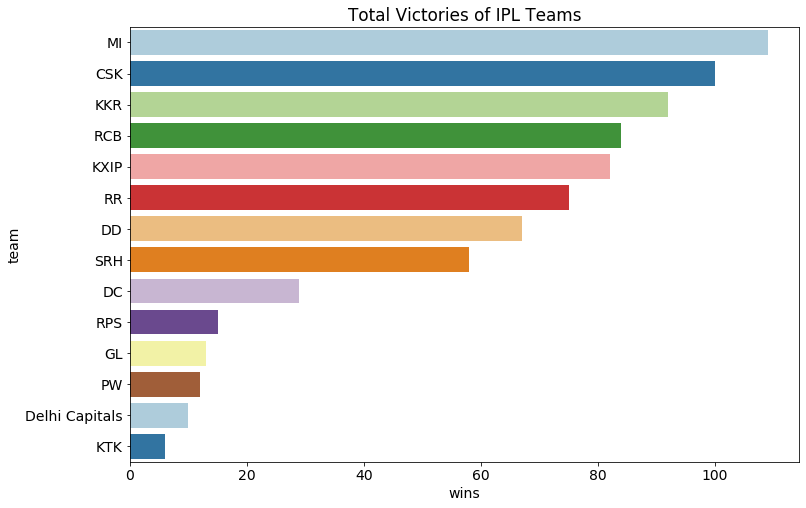

```python
plt.title("Total Victories of IPL Teams")
sns.barplot(x='wins', y='team', data=team_wins_df, palette='Paired');
```

# Observations:

## Mumbai Indians is the most successful team(as they have won the maximum number of IPL matches -109) followed by Chennai Super Kings and Kolkata Knight Riders.

### -------------------------------------------------------------------------------------------------------------------------------------------------------------

# ANALYSIS-4

## Most Valuable Player

### Winning matters the most in a competitive league match. If a player makes the most significant contribution to his team’s victory, then he’s chosen as the player_of_match. The player who has won the player_of_match title on most occasions is the most valuable player.

```python
mvp_ser = ipl_matches['player_of_match'].value_counts()

mvp_ten_df = pd.DataFrame(columns=["player", "wins"])
count = 0
for items in mvp_ser.iteritems():
    if count>9:
        break
    else:
        temp_df2 = pd.DataFrame({
            'player':[items[0]],
            'wins':[items[1]]
        })
        mvp_ten_df = mvp_ten_df.append(temp_df2, ignore_index=True)
        count += 1
```

```python
mvp_ten_df
```

|  | player | wins |
| --- | --- | --- |
| 0 | CH Gayle | 21 |
| 1 | AB de Villiers | 20 |
| 2 | MS Dhoni | 17 |
| 3 | DA Warner | 17 |
| 4 | RG Sharma | 17 |
| 5 | YK Pathan | 16 |
| 6 | SR Watson | 15 |
| 7 | SK Raina | 14 |
| 8 | G Gambhir | 13 |
| 9 | AM Rahane | 12 |

[figure not shown]

```python
plt.title("Top Ten IPL Players")
sns.barplot(x='wins', y='player', data=mvp_ten_df, palette='Paired');
```

# Observations:

## Cris Gayle is the player who won the most player of the match awards and hence is the most valuable player.

## Six Indian players have figured in the top ten IPL players list.

### -------------------------------------------------------------------------------------------------------------------------------------------------------------

# ANALYSIS-5

## The team that won the most number of toss

```python
toss_ser = ipl_matches['toss_winner'].value_counts()

toss_df = pd.DataFrame(columns=["team", "wins"])

for items in toss_ser.iteritems():
    temp_df3 = pd.DataFrame({
        'team':[items[0]],
        'wins':[items[1]]
    })
    toss_df = toss_df.append(temp_df3, ignore_index=True)
```

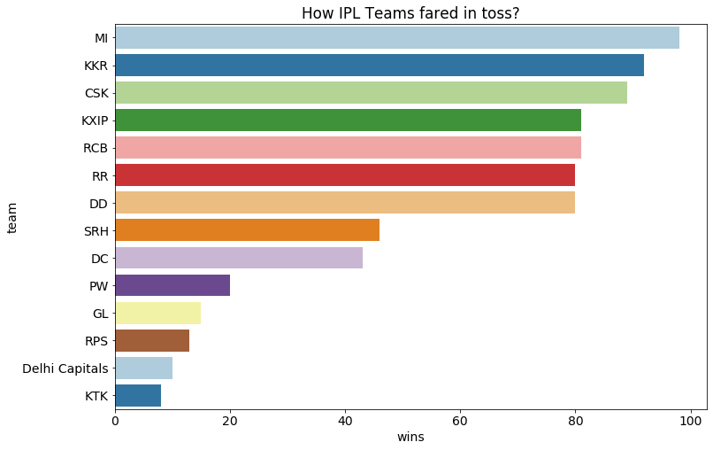

```python
plt.title("How IPL Teams fared in toss?")
sns.barplot(x='wins', y='team', data=toss_df, palette='Paired');
```

# Observations:

## Mumbai Indians has won the most toss(till 2019) in IPL history.

## All the top teams in IPL are successful in winning the toss as well.